# What's Your Astrological Sign?

Kateryna Savchyn  
Sun Aug 23 13:12:10 2015

### How It Works

It's extremely easy, you just put in the date you were born.

…that's pretty much it.

Based on your DOB, this web app tells you:

- your element
- your personality traits (both positive and negative) based on your sign
- see if you agree or think this is dumb!

### An Example

Here's an example of counts by astrological sign based on dates of birth for people born between Jan 1, 1969 and Dec 31, 1988 (from a dataset from Google's BigQuery, which I found [here](http://chmullig.com/2012/06/births-by-day-of-year/) ). It turns out finding datasets with dates of birth down to the day is sort of hard and the original National Vital Statistics System (NVSS) datasets are massive, so thankfully I was able to find this guy's query.

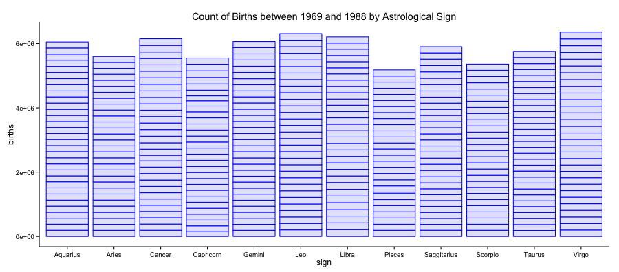

### Sources

Here's a list of pages I used to come up with the output for the app. Some of them might be interesting to check out.

- [Wikipedia Page on Western Astrology](https://en.wikipedia.org/wiki/Western_astrology)
- [Wikipedia Page on the Zodiac](https://en.wikipedia.org/wiki/Zodiac)
- [Wikipedia on Elements Based on Zodiac](https://en.wikipedia.org/wiki/Astrology_and_the_classical_elements#Elements_of_the_zodiac)
- [Some Freelance Writer's Article on Personalities Based on Star-Sign](https://medium.com/@evestanley/what-are-the-positive-and-negative-traits-of-your-zodiac-sign-e2d5b515536a)
- [Another Page on Zodiac-based Personality Traits](http://nuclear.ucdavis.edu/%7Erpicha/personal/astrology/)

## The End

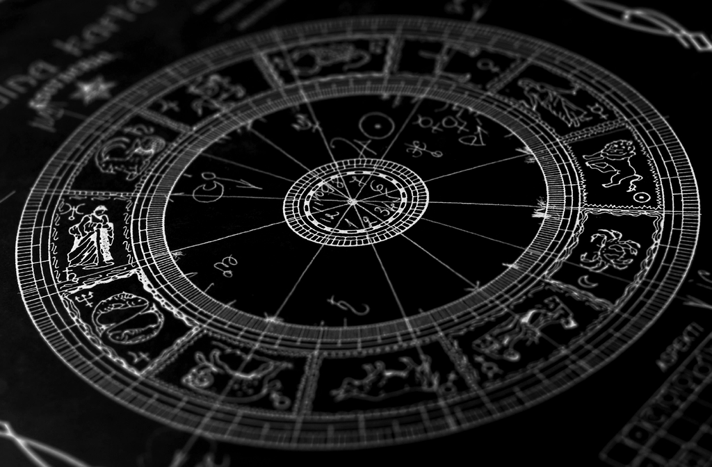